# First Draft

4/26/2022

# 1. Introduction

We analyzed a large data set of Amazon reviews separated by product category. The initial data set consists of 13 different tsv files, where each row represents a single review and its associated metadata, such as **review date**, **review text**, and **star rating**, etc.

# 2. Computation Steps

CHTC job requirements: the typical job time was between 1 - 6 minutes. We requested 1 GB of memory, and 3.5 GB of disk space per job.

# 3. Cleaned Data Summary

```
##                product_category      ratio            length
##  Mobile_Apps           :575026   Min.   :0.0000   Min.   :      0.0
##  Digital_Video_Download:497863   1st Qu.:0.3333   1st Qu.:     23.0
##  Automotive            :469685   Median :0.8333   Median :     54.0
##  Electronics           :416806   Mean   :0.6499   Mean   :    214.4
##  Grocery               :358650   3rd Qu.:1.0000   3rd Qu.:    156.0
##  Video Games           :308463   Max.   :1.0000   Max.   :1633296.0
##  (Other)               :789198
##  star_rating
##  1: 567116
##  2: 238161
##  3: 322034
##  4: 547013
##  5:1741367
##
##
```

## Independent Variables

*ratio*: the proportion of users that found the review helpful. If 5 users out of 10 flagged the review as helpful, the ratio for that review is 0.5. Review without any vote is removed from the data set.

*length*: the number of words in a review, counted as the number of character strings separated with a space (" ") as the delimiter.

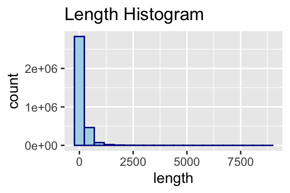

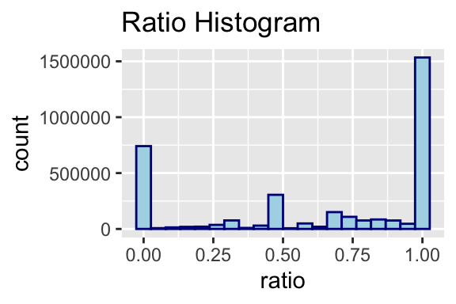

## Dependent Variables

*star_rating*: the rating of the product from 1 star to 5 stars. 1 star denotes the lowest possible rating, whereas 5 stars denotes the highest.

### Create a new variable `star1` and `star2`

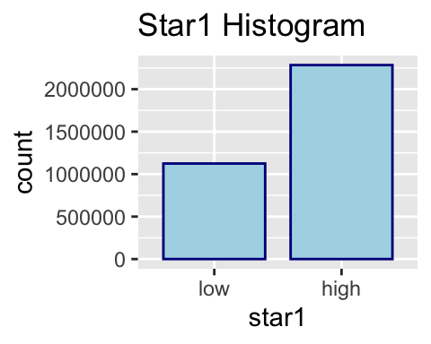

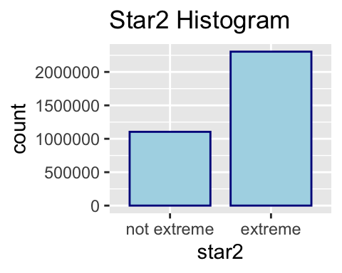

```
##
## Call:
## glm(formula = star1 ~ length * ratio, family = "binomial", data = df)
##
## Deviance Residuals:
##     Min       1Q   Median       3Q      Max
## -1.7604  -1.2619   0.7735   0.8620   3.2880
##
## Coefficients:
##                Estimate Std. Error z value Pr(>|z|)
## (Intercept)   1.990e-01  2.288e-03   86.98   <2e-16 ***
## length       -6.395e-04  9.715e-06  -65.82   <2e-16 ***
## ratio         8.527e-01  3.102e-03  274.88   <2e-16 ***
## length:ratio  6.691e-04  1.165e-05   57.43   <2e-16 ***
## ---
## Signif. codes:  0 '***' 0.001 '**' 0.01 '*' 0.05 '.' 0.1 ' ' 1
##
## (Dispersion parameter for binomial family taken to be 1)
##
##     Null deviance: 4322727  on 3408135  degrees of freedom
## Residual deviance: 4212056  on 3408132  degrees of freedom
## AIC: 4212064
##
## Number of Fisher Scoring iterations: 4
```

### odds estimator

```r
wald = confint.default(object = model1, level = 0.95)
est_df = cbind(exp(model1$coefficients),exp(wald))
est_df
```

```
##                            2.5 %    97.5 %
## (Intercept)  1.2201948 1.2147353 1.2256788
## length       0.9993607 0.9993417 0.9993797
## ratio        2.3460127 2.3317919 2.3603201
## length:ratio 1.0006693 1.0006465 1.0006922
```

### Model 2

Estimated Model: $logit(\hat{\pi}) = 0.6568 -0.0004length + 0.1871ratio + 0.0002length * ratio$

```
##
## Call:
## glm(formula = star2 ~ length * ratio, family = "binomial", data = df)
##
## Deviance Residuals:
##     Min       1Q   Median       3Q      Max
## -1.5502  -1.4618   0.8504   0.8862   2.5648
##
## Coefficients:
##                Estimate Std. Error z value Pr(>|z|)
## (Intercept)   6.568e-01  2.344e-03  280.23   <2e-16 ***
## length       -4.470e-04  8.685e-06  -51.46   <2e-16 ***
## ratio         1.871e-01  3.089e-03   60.57   <2e-16 ***
## length:ratio  2.466e-04  1.028e-05   24.00   <2e-16 ***
## ---
## Signif. codes:  0 '***' 0.001 '**' 0.01 '*' 0.05 '.' 0.1 ' ' 1
##
## (Dispersion parameter for binomial family taken to be 1)
##
##     Null deviance: 4293317  on 3408135  degrees of freedom
## Residual deviance: 4280647  on 3408132  degrees of freedom
## AIC: 4280655
##
## Number of Fisher Scoring iterations: 4
```

### odds estimator

```r
wald = confint.default(object = model2, level = 0.95)
est_df = cbind(exp(model2$coefficients),exp(wald))
est_df
```

```
##                            2.5 %    97.5 %
## (Intercept)  1.9286963 1.9198561 1.9375772
## length       0.9995531 0.9995361 0.9995701
## ratio        1.2057386 1.1984615 1.2130598
## length:ratio 1.0002466 1.0002265 1.0002668
```

### Interepration

# 5. Weakness

# 6. Conclusion